# Project 2 Report

Chanel Fraikin and Benjamin Kelly

2020-05-21

# Global Trajectory

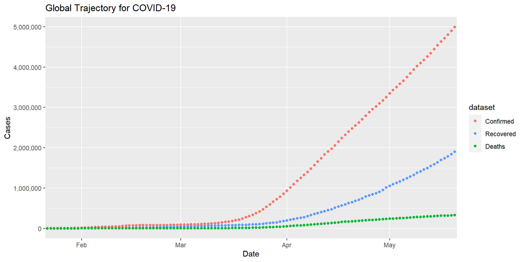

```r
# Load Datasets
confirmed_ds<-read.csv("time_series_covid19_confirmed_global.csv",
                       header=TRUE, stringsAsFactors=FALSE)
recovered_ds<-read.csv("time_series_covid19_recovered_global.csv",
                       header=TRUE, stringsAsFactors=FALSE)
deaths_ds<-read.csv("time_series_covid19_deaths_global.csv",
                    header=TRUE, stringsAsFactors=FALSE)

# Get totals per day through summation
confirmed_sum<-confirmed_ds%>%select(-(1:4))%>%summarise_all(sum)
recovered_sum<-recovered_ds%>%select(-(1:4))%>%summarise_all(sum)
death_sum<-deaths_ds%>%select(-(1:4))%>%summarise_all(sum)

# Merge datasets into one and add column for categories
dat <- rbind(confirmed_sum, recovered_sum, death_sum)
dat$dataset <- factor(c(rep("Confirmed", dim(confirmed_sum)[1]),
                        rep("Recovered", dim(recovered_sum)[1]),
                        rep("Deaths", dim(death_sum)[1])))

data_long <- gather(dat, Dates, SumCases, -dataset, factor_key=TRUE)

# Create Plot
ggplot(data_long, aes(x=Dates, y=SumCases, color=dataset)) +
  scale_color_discrete(breaks=c("Confirmed", "Recovered", "Deaths")) +
  geom_point() + ggtitle("Global Trajectory for COVID-19") +
  scale_x_discrete(breaks=c("X2.1.20","X3.1.20","X4.1.20", "X5.1.20"),
                   labels=c("Feb", "Mar", "Apr", "May")) +
  labs(y= "Cases", x = "Date") +
  scale_y_continuous(breaks=pretty_breaks(n=5),
                     labels=scales::comma)
```

# Global Map

```r
# Get data form last date which represents total
last_date <- names(confirmed_ds)[ncol(confirmed_ds)]
confirmed_last<-confirmed_ds%>%select(Province.State, Country.Region,
                                      Lat, Long, starts_with(last_date))
recovered_last<-recovered_ds%>%select(Province.State, Country.Region,
                                      Lat, Long, starts_with(last_date))
deaths_last<-deaths_ds%>%select(Province.State, Country.Region,
                                Lat, Long, starts_with(last_date))

# Rename last column to make calling it easier
# because R...
names(confirmed_last)[ncol(confirmed_last)]<-"Count"
names(recovered_last)[ncol(recovered_last)]<-"Count"
names(deaths_last)[ncol(deaths_last)]<-"Count"

# Merge data
dat <- rbind(confirmed_last, recovered_last, deaths_last)
dat$dataset <- factor(c(rep("Confirmed", dim(confirmed_last)[1]),
                        rep("Recovered", dim(recovered_last)[1]),
                        rep("Deaths", dim(deaths_last)[1])))

# Create a palette that maps factor levels to colors
pal <- colorFactor(c("blue", "cyan", "red"),
                   domain = c("Confirmed", "Recovered", "Deaths"))

# Create interactive map
leaflet(dat) %>% addTiles() %>%
  addCircles(
    radius = ~sqrt(dat$Count)*1000,
    color = ~pal(dataset),
    stroke = TRUE,
    fillOpacity = 0.4,
    group = ~dataset,
    label = paste(ifelse(dat$Province.State == "",
                         dat$Country.Region,
                         dat$Province.State)),
    popup = paste(dat$dataset, ": ",
                  format(dat$Count, big.mark=",", scientific=FALSE),
                  sep="")
    ) %>%
  addLayersControl(
    overlayGroups = c("Confirmed", "Recovered", "Deaths"),
    options = layersControlOptions(collapsed = FALSE)
    )
```

[interactive chart not shown]

# Narrowing Down Hot Spots

```r
# Combine Province/Country
confirmed_last$Location <- ifelse(confirmed_last$Province.State == "",
                                  paste(confirmed_last$Country.Region),
                                  paste(confirmed_last$Province.State,
                                    confirmed_last$Country.Region, sep=", "))
recovered_last$Location <- ifelse(recovered_last$Province.State == "",
                                  paste(recovered_last$Country.Region),
                                  paste(recovered_last$Province.State,
                                    recovered_last$Country.Region, sep=", "))
deaths_last$Location <- ifelse(deaths_last$Province.State == "",
                               paste(deaths_last$Country.Region),
                               paste(deaths_last$Province.State,
                                 deaths_last$Country.Region, sep=", "))

confirmed_totals<-arrange(select(confirmed_last, Location, Count), -Count)
recovered_totals<-arrange(select(recovered_last, Location, Count), -Count)
deaths_totals<-arrange(select(deaths_last, Location, Count), -Count)

# Rename columns so they do not get merged
names(confirmed_totals)<-c("Location_c", "Count_c")
names(recovered_totals)<-c("Location_r", "Count_r")
names(deaths_totals)<-c("Location_d", "Count_d")

max_rows<-max(nrow(confirmed_totals), nrow(recovered_totals),
              nrow(deaths_totals))

# Wanted to use cbind.fill here, but can't because R...
if (nrow(confirmed_totals) < max_rows) {
  empty_df<-data.frame(matrix(NA, nrow = (max_rows - nrow(confirmed_totals)),
                              ncol = 2))
  names(empty_df)<-c("Location_c", "Count_c")
  confirmed_totals<-rbind(confirmed_totals, empty_df)
}

if (nrow(recovered_totals) < max_rows) {
  empty_df<-data.frame(matrix(NA, nrow = (max_rows - nrow(recovered_totals)),
                              ncol = 2))
  names(empty_df)<-c("Location_r", "Count_r")
  recovered_totals<-rbind(recovered_totals, empty_df)
}

if (nrow(deaths_totals) < max_rows) {
  empty_df<-data.frame(matrix(NA, nrow = (max_rows - nrow(deaths_totals)),
                              ncol = 2))
  names(empty_df)<-c("Location_d", "Count_d")
  deaths_totals<-rbind(deaths_totals, empty_df)
}

total_ds<-cbind(confirmed_totals, recovered_totals, deaths_totals)

# Add Ranking column
total_ds<-cbind(data.frame(Rank=rownames(total_ds)), total_ds)

# Make Kabble Table
total_ds %>%
  kable(col.names = c("Rank", "Country", "Count", "Country",
                      "Count", "Country", "Count"),
        format.args = list(big.mark = ",", scientific = FALSE),
        caption="Table of Top Countries") %>%
  kable_styling("striped") %>%
  add_header_above(c(" " = 1, "Confirmations" = 2,
                     "Recoveries" = 2, "Deaths" = 2)) %>%
  scroll_box(width = "100%", height = "600px")
```

Table of Top Countries

| Rank | Confirmations Country | Confirmations Count | Recoveries Country | Recoveries Count | Deaths Country | Deaths Count |
| --- | --- | --- | --- | --- | --- | --- |
| 1 | US | 1,551,853 | US | 294,312 | US | 93,439 |
| 2 | Russia | 308,705 | Germany | 156,966 | United Kingdom | 35,704 |
| 3 | Brazil | 291,579 | Spain | 150,376 | Italy | 32,330 |
| 4 | United Kingdom | 248,293 | Italy | 132,282 | France | 28,084 |
| 5 | Spain | 232,555 | Brazil | 116,683 | Spain | 27,888 |
| 6 | Italy | 227,364 | Turkey | 113,987 | Brazil | 18,859 |
| 7 | France | 179,069 | Iran | 98,808 | Belgium | 9,150 |
| 8 | Germany | 178,473 | Russia | 85,392 | Germany | 8,144 |
| 9 | Turkey | 152,587 | Hubei, China | 63,616 | Iran | 7,183 |
| 10 | Iran | 126,949 | France | 61,713 | Mexico | 6,090 |
| 11 | India | 112,028 | India | 45,422 | Netherlands | 5,748 |
| 12 | Peru | 104,020 | Peru | 41,968 | Hubei, China | 4,512 |
| 13 | Hubei, China | 68,135 | Canada | 40,793 | Turkey | 4,222 |
| 14 | Saudi Arabia | 62,545 | Mexico | 38,419 | Sweden | 3,831 |
| 15 | Mexico | 56,594 | Saudi Arabia | 33,478 | Quebec, Canada | 3,719 |
| 16 | Belgium | 55,983 | Switzerland | 27,800 | India | 3,434 |
| 17 | Chile | 53,617 | Chile | 22,504 | Peru | 3,024 |
| 18 | Pakistan | 45,898 | Ireland | 21,060 | Russia | 2,972 |
| 19 | Quebec, Canada | 44,784 | Austria | 14,882 | Ecuador | 2,888 |
| 20 | Netherlands | 44,447 | Belgium | 14,847 | Ontario, Canada | 2,079 |
| 21 | Qatar | 37,097 | Israel | 13,504 | Switzerland | 1,892 |
| 22 | Ecuador | 34,854 | Pakistan | 13,101 | Ireland | 1,571 |
| 23 | Belarus | 32,426 | United Arab Emirates | 11,809 | Portugal | 1,263 |
| 24 | Sweden | 31,523 | Japan | 11,564 | Indonesia | 1,242 |
| 25 | Switzerland | 30,658 | Belarus | 11,415 | Romania | 1,147 |
| 26 | Portugal | 29,660 | Singapore | 11,207 | Pakistan | 985 |
| 27 | Singapore | 29,364 | Romania | 10,356 | Poland | 962 |
| 28 | Bangladesh | 26,738 | Korea, South | 10,135 | Philippines | 842 |
| 29 | United Arab Emirates | 26,004 | Denmark | 9,536 | Japan | 768 |
| 30 | Ontario, Canada | 25,197 | South Africa | 8,950 | Egypt | 680 |

[output cut: 236 more lines]

# Zooming Into Our State

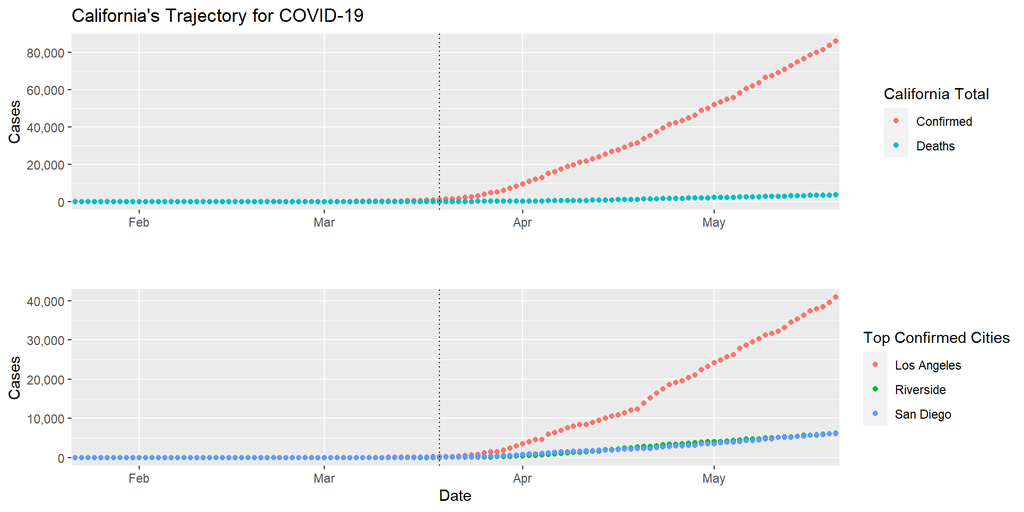

```r
# Load Datasets
confirmed_ds<-read.csv("time_series_covid19_confirmed_US.csv",
                       header=TRUE, stringsAsFactors=FALSE)
deaths_ds<-read.csv("time_series_covid19_deaths_US.csv",
                    header=TRUE, stringsAsFactors=FALSE)

# Get totals per day through summation
confirmed_sum<-confirmed_ds %>%
  filter(Province_State=="California") %>%
  select(-(1:11)) %>%
  summarise_all(sum)

death_sum<-deaths_ds %>%
  filter(Province_State=="California") %>%
  select(-(1:12)) %>%
  summarise_all(sum)

# Merge datasets into one and add column for categories
dat <- rbind(confirmed_sum, death_sum)
dat$dataset <- factor(c(rep("Confirmed", dim(confirmed_sum)[1]),
                        rep("Deaths", dim(death_sum)[1])))

data_long <- gather(dat, Dates, SumCases, -dataset, factor_key=TRUE)

# Create Plot
p1<-ggplot(data_long, aes(x=Dates, y=SumCases, color=dataset)) +
  scale_color_discrete(name= "California Total",
                       breaks=c("Confirmed", "Deaths")) +
  geom_point() + ggtitle("California's Trajectory for COVID-19") +
  scale_x_discrete(breaks=c("X2.1.20","X3.1.20","X4.1.20", "X5.1.20"),
                   labels=c("Feb", "Mar", "Apr", "May")) +
  labs(y= "Cases", x= "") +
  scale_y_continuous(breaks=pretty_breaks(n=5),
                     labels=scales::comma)+
  geom_vline(xintercept="X3.19.20", linetype="dotted")

# Second scatter plot
top_confirmed_cities<-confirmed_ds %>%
  filter(Province_State=="California") %>%
  group_by(Admin2) %>%
  select(-(1:11)) %>%
  summarise_all(sum) %>%
  arrange_at(ncol(.), desc)

dat<-top_confirmed_cities[1:3,]
city_names<-c(dat[[1,1]], dat[[2,1]], dat[[3,1]])
data_long <- gather(dat, Dates, SumCases, -Admin2, factor_key=TRUE)

# Create Plot
p2<-ggplot(data_long, aes(x=Dates, y=SumCases, color=Admin2)) +
  scale_color_discrete(name="Top Confirmed Cities",
                       breaks=c(city_names[1], city_names[2], city_names[3])) +
  geom_point() +
  scale_x_discrete(breaks=c("X2.1.20","X3.1.20","X4.1.20", "X5.1.20"),
                   labels=c("Feb", "Mar", "Apr", "May")) +
  labs(y= "Cases", x = "Date") +
  scale_y_continuous(breaks=pretty_breaks(n=5),
                     labels=scales::comma) +
   geom_vline(xintercept="X3.19.20", linetype="dotted")

plot_grid(p1, p2, nrow = 2, ncol = 1, align="hv")
```

# Digging Deeper

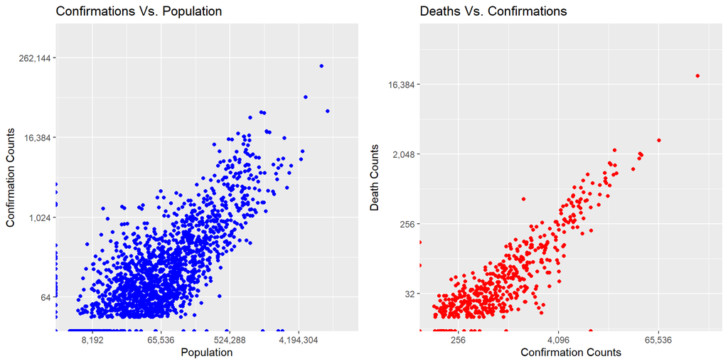

```r
# Rename last column because R...
names(confirmed_ds)[ncol(confirmed_ds)]<-"Counts_c"
names(deaths_ds)[ncol(deaths_ds)]<-"Counts_d"

# Grab data for location population and counts on the last day
confirmed_data<-select(confirmed_ds, Admin2, Province_State, Counts_c)
deaths_data<-select(deaths_ds, Admin2, Province_State, Population, Counts_d)

# Join data frames based on location
total_data<-full_join(confirmed_data, deaths_data,
                       by=c("Admin2", "Province_State"))

# Create Confirmations vs Population plot
p1<-ggplot(total_data, aes(x=Population, y=Counts_c)) +
  geom_point(color="blue") + ggtitle("Confirmations Vs. Population") +
  scale_x_log10(breaks=c(2^13, 2^16, 2^19, 2^22), labels=scales::comma,
                         limits=c(2^12, 2^24)) +
  scale_y_log10(breaks=c(2^6, 2^10, 2^14, 2^18), labels=scales::comma,
                limits=c(2^5, 2^19)) +
  labs(y= "Confirmation Counts", x= "Population")

# Create Deaths vs Confirmations plot
p2<-ggplot(total_data, aes(x=Counts_c, y=Counts_d)) +
  geom_point(color="red") + ggtitle("Deaths Vs. Confirmations") +
  scale_x_log10(breaks=c(2^8, 2^12, 2^16), labels=scales::comma,
                         limits=c(2^7, 2^18)) +
  scale_y_log10(breaks=c(2^5, 2^8, 2^11, 2^14), labels=scales::comma,
                limits=c(2^4, 2^16)) +
  labs(y= "Death Counts", x= "Confirmation Counts")

# Horizontially stack plots
plot_grid(p1, p2, nrow = 1, ncol = 2, align="hv")
```

# GitHub Log

Bash script not working on my PC. This is the output when running the script from the command line:

Subject: Updating datasets to latest, small update to problems 2 & 3 to use commas in numbering  
Author: 007Stylex007 (Benjamin Kelly)  
Date: Thu, 21 May 2020 18:31:15 -0700  
Body:

Subject: Uploading current HTML Document  
Author: 007Stylex007 (Benjamin Kelly)  
Date: Wed, 20 May 2020 21:06:27 -0700  
Body:

Subject: Updates to problem 4 to enable it to work with generic data. Implemented problem 5  
Author: 007Stylex007 (Benjamin Kelly)  
Date: Wed, 20 May 2020 20:54:43 -0700  
Body:

Subject: Revisions to Question 4  
Author: Chanel Fraikin  
Date: Wed, 20 May 2020 15:56:58 -0700  
Body:

Subject: Implemented Question 4  
Author: Chanel Fraikin  
Date: Wed, 20 May 2020 15:45:23 -0700  
Body:

Subject: Minor improvements with problem 2. Implemented problem 3.  
Author: 007Stylex007 (Benjamin Kelly)  
Date: Tue, 19 May 2020 22:14:04 -0700  
Body:

Subject: Updated problems 1 & 2 to be used with generic data. Updated labels and popups on map to be dynamic based on data frame.  
Author: 007Stylex007 (Benjamin Kelly)  
Date: Tue, 19 May 2020 20:06:40 -0700  
Body:

Subject: Reverting document format to html  
Author: 007Stylex007 (Benjamin Kelly)  
Date: Tue, 19 May 2020 18:36:15 -0700  
Body:

Subject: Merge branch ‘master’ of https://github.com/cfraikin/Project-2  
Author: Chanel Fraikin  
Date: Mon, 18 May 2020 20:28:09 -0700  
Body:

Subject: Obj 2 draft complete  
Author: Chanel Fraikin  
Date: Mon, 18 May 2020 20:27:54 -0700  
Body:

Subject: Updated report format and updated problem 1 y axis scale  
Author: 007Stylex007 (Benjamin Kelly)  
Date: Mon, 18 May 2020 19:30:45 -0700  
Body:

Subject: added rest of data and did first objective  
Author: Chanel Fraikin  
Date: Mon, 18 May 2020 18:09:35 -0700  
Body:

Subject: downloaded US data on 5/15/20  
Author: Chanel Fraikin  
Date: Fri, 15 May 2020 13:51:05 -0700  
Body:

Subject: Created report  
Author: Chanel Fraikin  
Date: Fri, 15 May 2020 13:36:51 -0700  
Body:

Subject: Update README.md  
Author: cfraikin  
Date: Fri, 15 May 2020 13:26:51 -0700  
Body:

Subject: Initial commit  
Author: cfraikin  
Date: Fri, 15 May 2020 13:24:42 -0700  
Body: